# How Do Clusters Covary with Eachother?

Libraries

```r
library(Seurat)
library(tidyverse)
library(pheatmap)
library(ggplot2)
set.seed(123)
```

Read in Object

```r
obj <- readRDS('C:/Users/Gabe/Desktop/RNA Object.rds')
```

## Proportion of each cluster within each individual, **which clusters may be dissection errors?**

```r
individuals <- unique(obj$individual)
```

```r
proportion_of_each_cluster_within_each_individual <- matrix(0, length(individuals), 32)
rownames(proportion_of_each_cluster_within_each_individual) <- individuals
colnames(proportion_of_each_cluster_within_each_individual) <- 0:31

for(c in 0:31){
  #calculate total cells in cluster
  total_cells <- nrow(obj@meta.data[obj$harmony.wnn_res0.4_clusters==c,])

  cluster_index <- which(colnames(proportion_of_each_cluster_within_each_individual)==c)
  for(i in individuals){
    #calculate total cells in individual in cluster
    total_cells_individual <- nrow(obj@meta.data[obj$harmony.wnn_res0.4_clusters==c & obj$individual==i,])

    prop <- total_cells_individual/ total_cells

    individual_index <- which(rownames(proportion_of_each_cluster_within_each_individual)==i)

    proportion_of_each_cluster_within_each_individual[individual_index,cluster_index] = prop
  }
}
```

Plot heatmap

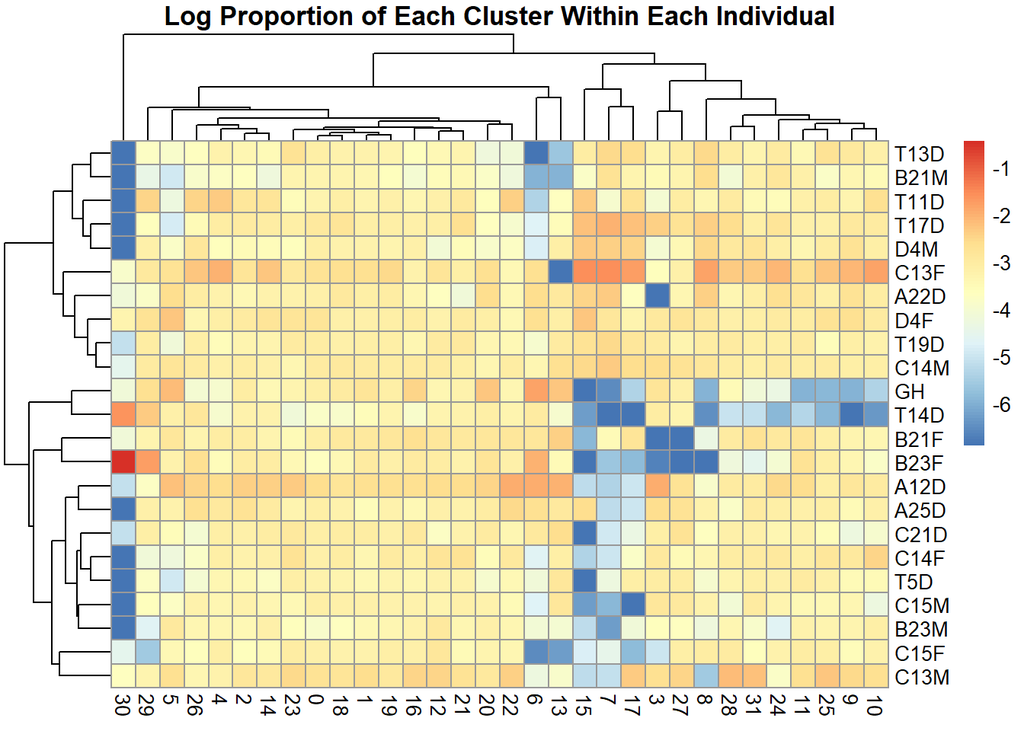

```r
pheatmap(log(proportion_of_each_cluster_within_each_individual+0.001),
         main='Log Proportion of Each Cluster Within Each Individual')
```

Here, we can see a few things.

1. It seems like 15, 7, and 17 are likely near eachother in space, as it seems like they covary eachother in their absence / low proportion in several individuals. 15 We already considered a dissection error, I still think the other two are high enough quality to not exclude. It doesnt seem like this dissection difference is restrictricted to a specific sex. In my opinion, these are hypothalamus.
2. GH is indeed poorly dissected , T14D is also a bit strange.
3. 30 Should definitely be exluded

Plot with K Means clustering

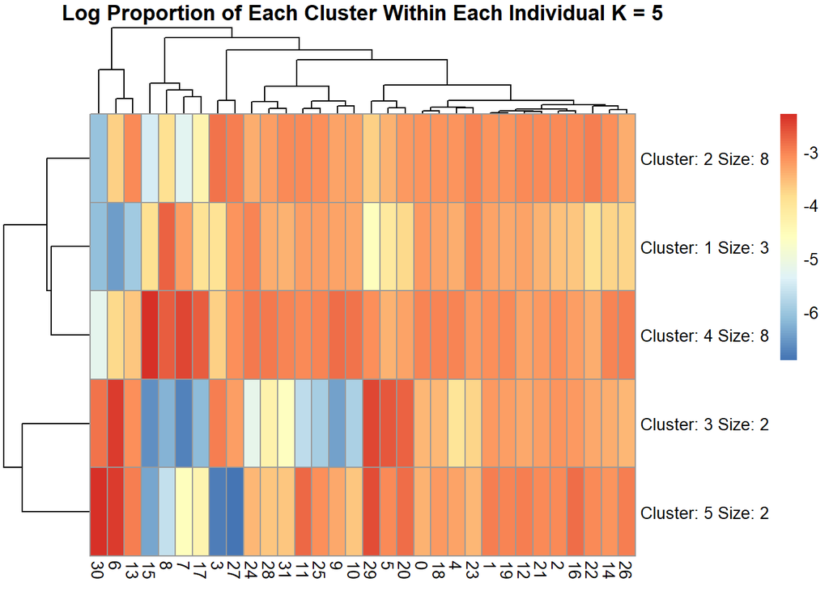

```r
pheatmap(log(proportion_of_each_cluster_within_each_individual+0.001),
         k  = 5,
         main='Log Proportion of Each Cluster Within Each Individual K = 5')
```

Here, our clusters are individuals. It doesn’t seem like there is any strong pattern (beyond cluster 3 which is T14D and GH) which is good and means there probably wasnt a big sex difference in dissections.

Plot dendogram

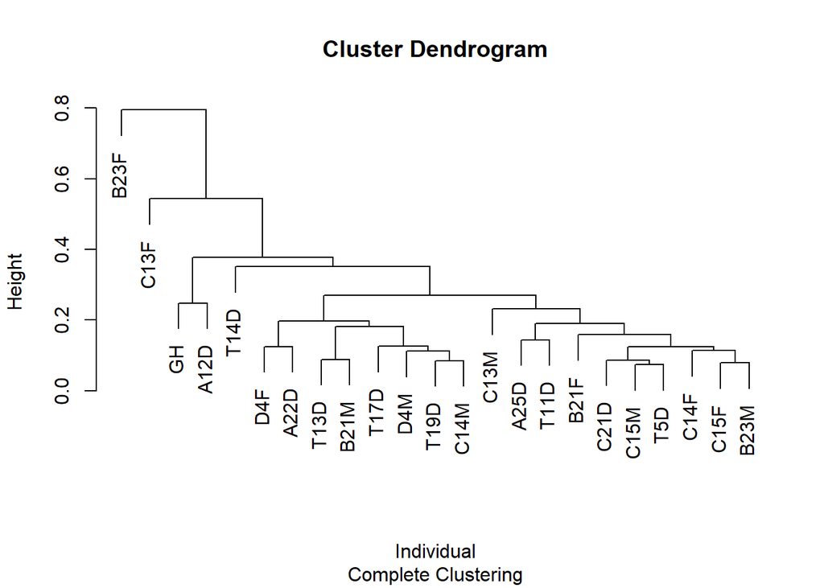

```r
poecwei_hierarchical <- hclust(dist(proportion_of_each_cluster_within_each_individual))
plot(poecwei_hierarchical, xlab ='Individual', sub = 'Complete Clustering')
```

Here, B23F is the most weird, in the first heatmap she has the most cells from garbage cluster 30 and is missing a few cells in some clusters. All others seem largely similar.

## Proportion of each individual within each cluster, **which individuals are overrepresented in clusters?**

```r
proportion_of_each_individual_within_each_cluster <- matrix(0, length(individuals), 32)
rownames(proportion_of_each_individual_within_each_cluster) <- individuals
colnames(proportion_of_each_individual_within_each_cluster) <- 0:31

for(i in individuals){
  individual_index <- which(rownames(proportion_of_each_individual_within_each_cluster)==i)

  total_cells_in_fish <- nrow(obj@meta.data[obj$individual==i,])
  for(c in 0:31){
    cluster_index <- which(colnames(proportion_of_each_individual_within_each_cluster)==c)

    cells_in_fish_in_cluster <- nrow(obj@meta.data[obj$individual==i & obj$harmony.wnn_res0.4_clusters ==c,])

    prop = cells_in_fish_in_cluster / total_cells_in_fish

    proportion_of_each_individual_within_each_cluster[individual_index,cluster_index] = prop

  }

}
```

Plot heatmap

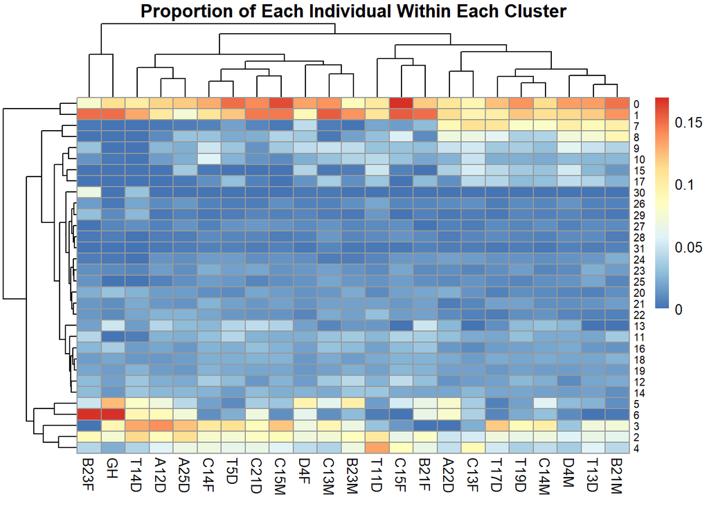

```r
pheatmap(t(proportion_of_each_individual_within_each_cluster),
         main='Proportion of Each Individual Within Each Cluster',
         fontsize_row = 7.5)
```

Here, we see that clusters 0 and covary with eachother beyond the levels of other clusters.

Plot with k means clustering k = 5

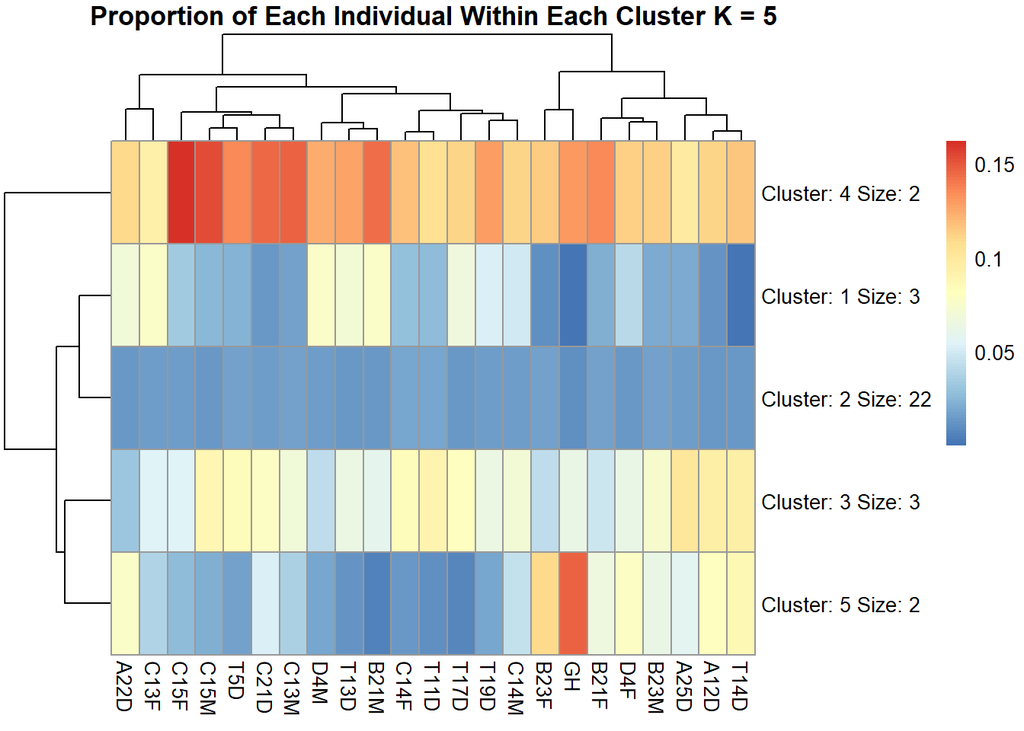

```r
pheatmap(t(proportion_of_each_individual_within_each_cluster),k = 5,
         main='Proportion of Each Individual Within Each Cluster K = 5')
```

Here, clusters are groups of clusters, we see that 0 and 1 cluster together (cluster 4) separately from the others.

Plot dendogram

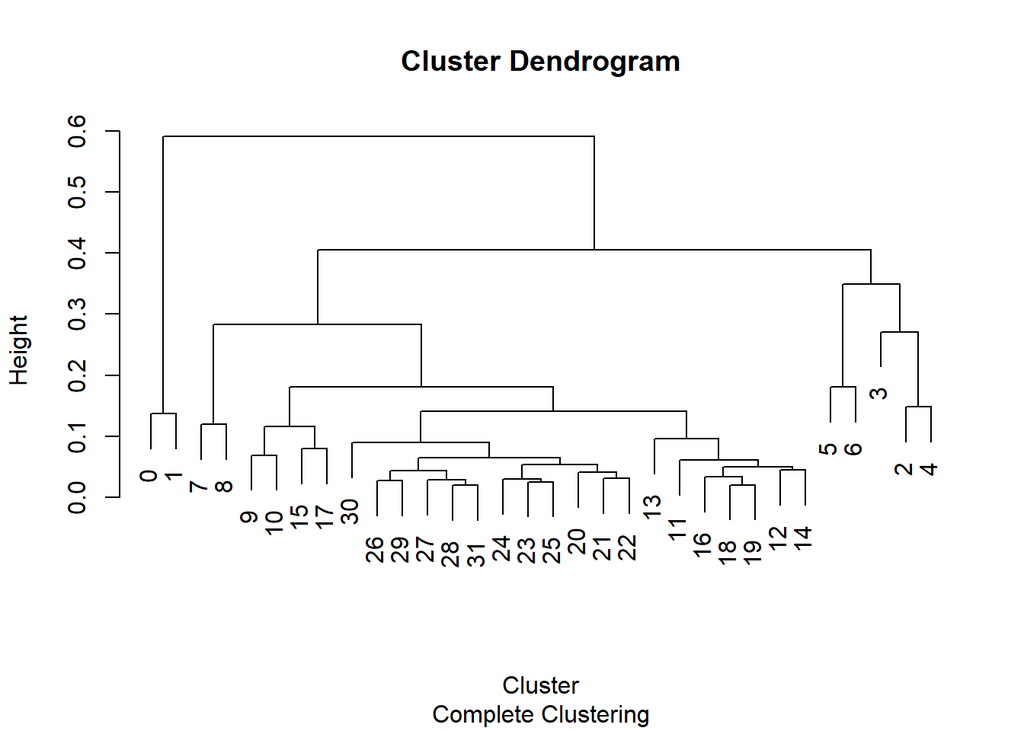

```r
poeiwec_hierarchical <- hclust(dist(t(proportion_of_each_individual_within_each_cluster)))
plot(poeiwec_hierarchical, xlab ='Cluster', sub = 'Complete Clustering')
```

Again, we see clusters 0 and 1 cluster together. Also interesting, 6 and 5 cluster together and near 3. 6 is very likely Dm, so its likely 5 and 3 are also superior to the POA. None of these clusters aligned to POA in our alignment. 3 is our gal+ cluster.

## Mean and SD of relative proportions of each individual within each cluster, **are any clusters particularly variable?**

```r
mean_and_sd = as.data.frame(t(proportion_of_each_individual_within_each_cluster))
mean_and_sd$cluster = rownames(mean_and_sd)

mean_and_sd_summarized <- mean_and_sd %>%
  pivot_longer(cols = -cluster, names_to = "individual", values_to = "value") %>%
  group_by(cluster) %>%
  summarize(
    mean_value = mean(value, na.rm = TRUE),
    sd_value = sd(value, na.rm = TRUE)
  )
```

Plot means

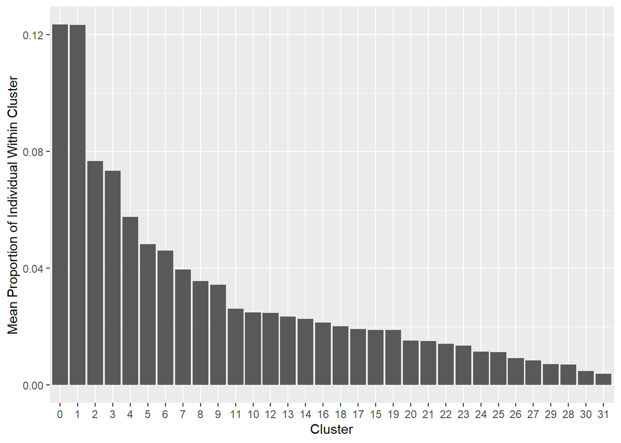

```r
ggplot(mean_and_sd_summarized, aes(x = fct_reorder(cluster,mean_value, .desc = T), y = mean_value))+
  geom_bar(stat = 'identity')+
  labs(x = 'Cluster', y = 'Mean Proportion of Individual Within Cluster')
```

0 and 1 are in nearly identical proportion in terms of proportion of each individual represented within them.

Plot SDs

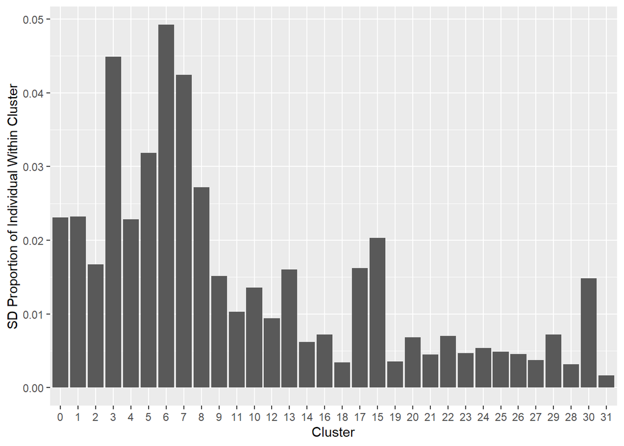

```r
ggplot(mean_and_sd_summarized, aes(x = fct_reorder(cluster,mean_value, .desc = T), y = sd_value))+
  geom_bar(stat = 'identity')+
  labs(x = 'Cluster', y = 'SD Proportion of Individual Within Cluster')
```

Again, 0 and 1 have nearly identical standard deviations. Consistent with the idea that 3,5,and 6 were partially dissected out, they have higher standard deviation. Also interestingly, 17 and 15 covary with eachother supporting the idea they are near eachother in space.

## Correlation Between Cluster 0 and 1

```r
cor.test(proportion_of_each_individual_within_each_cluster[,'0'],proportion_of_each_individual_within_each_cluster[,'1'] )
```

```
##
##  Pearson's product-moment correlation
##
## data:  proportion_of_each_individual_within_each_cluster[, "0"] and proportion_of_each_individual_within_each_cluster[, "1"]
## t = 0.9415, df = 21, p-value = 0.3572
## alternative hypothesis: true correlation is not equal to 0
## 95 percent confidence interval:
##  -0.2300362  0.5664601
## sample estimates:
##       cor
## 0.2012487
```

Not a great correlation

[figure not shown]

```r
plot(x =proportion_of_each_individual_within_each_cluster[,'0'],
     y =proportion_of_each_individual_within_each_cluster[,'1'] ,
     xlab = 'Cluster 1', ylab = 'Cluster 0')
```

## Taken together

1. Clusters 0 and 1 are in nearly identical proportion to eachother (in this current paradigm)
2. 15 and 17 were likely partially dissected as well as 5 and 6

In my opinion, this data is of good enough quality that subsetting out GH and 15 and 30 is fine.